# Notebook

# **Customer Lifecycle SQL**

**1. Acquisition & Activation (The Start)**

```python
c.execute('''WITH cte as(SELECT c.customer_unique_id as cust_id, strftime('%Y-%m',o.order_purchase_timestamp) as year_month,  ROW_NUMBER() OVER (
            PARTITION BY c.customer_unique_id
            ORDER BY o.order_purchase_timestamp
        ) as rn
            FROM olist_customers_dataset as c
            JOIN olist_orders_dataset as o
            ON c.customer_id = o.customer_id)

            SELECT year_month,count(cust_id) as cnt from cte
            GROUP BY year_month
            ORDER BY cnt desc
          ;
''')
df = pd.DataFrame(c.fetchall(), columns=['Year-Month','Count'])
display(df)
```

|  | Year-Month | Count |
| --- | --- | --- |
| 0 | 2017-11 | 7544 |
| 1 | 2018-01 | 7269 |
| 2 | 2018-03 | 7211 |
| 3 | 2018-04 | 6939 |
| 4 | 2018-05 | 6873 |
| 5 | 2018-02 | 6728 |
| 6 | 2018-08 | 6512 |
| 7 | 2018-07 | 6292 |
| 8 | 2018-06 | 6167 |
| 9 | 2017-12 | 5673 |
| 10 | 2017-10 | 4631 |
| 11 | 2017-08 | 4331 |
| 12 | 2017-09 | 4285 |
| 13 | 2017-07 | 4026 |
| 14 | 2017-05 | 3700 |
| 15 | 2017-06 | 3245 |
| 16 | 2017-03 | 2682 |
| 17 | 2017-04 | 2404 |
| 18 | 2017-02 | 1780 |
| 19 | 2017-01 | 800 |
| 20 | 2016-10 | 324 |
| 21 | 2018-09 | 16 |
| 22 | 2018-10 | 4 |
| 23 | 2016-09 | 4 |
| 24 | 2016-12 | 1 |

**First Purchase Category**: Which product categories are most effective at "acquiring" new customers?

```python
c.execute('''WITH first_orders AS (
    SELECT
        c.customer_unique_id,
        o.order_id,
        o.order_purchase_timestamp,
        ROW_NUMBER() OVER (
            PARTITION BY c.customer_unique_id
            ORDER BY o.order_purchase_timestamp
        ) as rn
    FROM olist_customers_dataset c
    JOIN olist_orders_dataset o
        ON c.customer_id = o.customer_id
),

first_order_items AS (
    SELECT
        f.customer_unique_id,
        p.product_category_name
    FROM first_orders f
    JOIN olist_order_items_dataset i
        ON f.order_id = i.order_id
    JOIN olist_products_dataset p
        ON i.product_id = p.product_id
    WHERE f.rn = 1
)

SELECT
    product_category_name,
    COUNT(DISTINCT customer_unique_id) as customer_count
FROM first_order_items
GROUP BY product_category_name
ORDER BY customer_count DESC;
''')
df = pd.DataFrame(c.fetchall(), columns=['Product','Count'])
display(df)
```

|  | Product | Count |
| --- | --- | --- |
| 0 | cama_mesa_banho | 8952 |
| 1 | beleza_saude | 8561 |
| 2 | esporte_lazer | 7399 |
| 3 | informatica_acessorios | 6464 |
| 4 | moveis_decoracao | 6137 |
| ... | ... | ... |
| 69 | la_cuisine | 13 |
| 70 | cds_dvds_musicais | 12 |
| 71 | fashion_roupa_infanto_juvenil | 8 |
| 72 | pc_gamer | 7 |
| 73 | seguros_e_servicos | 2 |

74 rows × 2 columns

# **2. Retention & Engagement (The Middle)**

**Repeat Purchase Rate:** What percentage of your customers have more than one order_id associated with their customer_unique_id?

```python
c.execute('''
WITH UserOrderCounts AS (
    SELECT
        c.customer_unique_id,
        COUNT(o.order_id) as order_count
    FROM olist_customers_dataset c
    JOIN olist_orders_dataset o ON c.customer_id = o.customer_id
    GROUP BY c.customer_unique_id
)

SELECT
    COUNT(CASE WHEN order_count > 1 THEN 1 END) * 100.0 / COUNT(*) AS repeat_purchase_rate
FROM UserOrderCounts;
''')

df = pd.DataFrame(c.fetchall(), columns=['Repeat Purchase Rate (%)'])
display(df)
```

|  | Repeat Purchase Rate (%) |
| --- | --- |
| 0 | 3.118756 |

**Purchase Frequency**: What is the average number of days between the first and second purchase?

```python
c.execute('''WITH OrderSequences as(
    SELECT
        c.customer_unique_id,
        o.order_id,
        o.order_purchase_timestamp as current_order_date,
        ROW_NUMBER() OVER (
            PARTITION BY c.customer_unique_id
            ORDER BY o.order_purchase_timestamp
            ) as order_number,
            LAG(o.order_purchase_timestamp) OVER (
            PARTITION BY c.customer_unique_id
            ORDER BY o.order_purchase_timestamp
            ) as prev_order_timestamp
    FROM olist_customers_dataset c
    JOIN olist_orders_dataset o
    ON c.customer_id = o.customer_id)

    SELECT
    order_number,
    AVG(julianday(current_order_date) - julianday(prev_order_timestamp)) as avg_days_since_prior
    FROM OrderSequences
    WHERE order_number IN (2, 3)
    GROUP BY order_number;

''')
df = pd.DataFrame(c.fetchall(), columns=['Order','Average Days'])
display(df)
```

|  | Order | Average Days |
| --- | --- | --- |
| 0 | 2 | 80.349981 |
| 1 | 3 | 60.625089 |

**Cohort Retention:** If you group customers by the month of their first purchase (Jan 2017, Feb 2017, etc.), what percentage of each group returns to buy again in Month 1, Month 2, or Month 6?

```python
c.execute('''WITH customer_first_purchase AS (
    SELECT
        c.customer_unique_id,
        strftime('%Y-%m', MIN(o.order_purchase_timestamp)) AS cohort_month
    FROM olist_customers_dataset c
    JOIN olist_orders_dataset o ON c.customer_id = o.customer_id
    GROUP BY c.customer_unique_id
),
customer_purchases AS (
    SELECT DISTINCT
        c.customer_unique_id,
        strftime('%Y-%m', o.order_purchase_timestamp) AS purchase_month
    FROM olist_customers_dataset c
    JOIN olist_orders_dataset o ON c.customer_id = o.customer_id
),
cohort_analysis AS (
    SELECT
        cfp.customer_unique_id,
        cfp.cohort_month,
        cp.purchase_month,
        (CAST(substr(cp.purchase_month, 1, 4) AS INT) - CAST(substr(cfp.cohort_month, 1, 4) AS INT)) * 12 +
        (CAST(substr(cp.purchase_month, 6, 2) AS INT) - CAST(substr(cfp.cohort_month, 6, 2) AS INT)) AS month_index
    FROM customer_first_purchase cfp
    JOIN customer_purchases cp ON cfp.customer_unique_id = cp.customer_unique_id
)
SELECT
    cohort_month,
    month_index,
    COUNT(DISTINCT customer_unique_id) AS total_users
FROM cohort_analysis
GROUP BY cohort_month, month_index
ORDER BY cohort_month, month_index;
''')
df_cohort = pd.DataFrame(c.fetchall(), columns=['Cohort Month','Month Index','Total Users'])
display(df_cohort)
```

|  | Cohort Month | Month Index | Total Users |
| --- | --- | --- | --- |
| 0 | 2016-09 | 0 | 4 |
| 1 | 2016-10 | 0 | 321 |
| 2 | 2016-10 | 6 | 1 |
| 3 | 2016-10 | 9 | 1 |
| 4 | 2016-10 | 11 | 1 |
| ... | ... | ... | ... |
| 220 | 2018-08 | 0 | 6271 |
| 221 | 2018-08 | 1 | 7 |
| 222 | 2018-08 | 2 | 2 |
| 223 | 2018-09 | 0 | 5 |
| 224 | 2018-10 | 0 | 1 |

225 rows × 3 columns

# **3. Monetization (The Value)**

**Customer Lifetime Value (CLV)**: What is the total payment_value associated with a customer_unique_id across all their orders?

```python
c.execute('''SELECT c.customer_unique_id,sum(p.payment_value) as payment
FROM olist_customers_dataset c
JOIN olist_orders_dataset o ON c.customer_id = o.customer_id
JOIN olist_order_payments_dataset p ON o.order_id = p.order_id
GROUP BY c.customer_unique_id
ORDER BY payment DESC''')
df = pd.DataFrame(c.fetchall(), columns=['Customer_id','Payment Across Orders'])
display(df)
```

|  | Customer_id | Payment Across Orders |
| --- | --- | --- |
| 0 | 0a0a92112bd4c708ca5fde585afaa872 | 13664.08 |
| 1 | 46450c74a0d8c5ca9395da1daac6c120 | 9553.02 |
| 2 | da122df9eeddfedc1dc1f5349a1a690c | 7571.63 |
| 3 | 763c8b1c9c68a0229c42c9fc6f662b93 | 7274.88 |
| 4 | dc4802a71eae9be1dd28f5d788ceb526 | 6929.31 |
| ... | ... | ... |
| 96090 | b33336f46234b24a613ad9064d13106d | 10.89 |
| 96091 | bd06ce0e06ad77a7f681f1a4960a3cc6 | 10.07 |
| 96092 | 317cfc692e3f86c45c95697c61c853a6 | 9.59 |
| 96093 | 968fac81e2c44fb6c1e3ac2a45e6a102 | 0.00 |
| 96094 | 4fa4365000c7090fcb8cad5713c6d3db | 0.00 |

96095 rows × 2 columns

**Average Order Value (AOV) Growth:** Does a customer’s second or third order typically have a higher value than their first?

```python
c.execute('''WITH OrderTotalValues AS (
    SELECT order_id, SUM(payment_value) as total_value
    FROM olist_order_payments_dataset
    GROUP BY 1
),
CustomerOrderSequence AS (
    SELECT
        c.customer_unique_id,
        otv.total_value,
        ROW_NUMBER() OVER (
            PARTITION BY c.customer_unique_id
            ORDER BY o.order_purchase_timestamp
        ) as order_rank
    FROM olist_orders_dataset o
    JOIN olist_customers_dataset c ON o.customer_id = c.customer_id
    JOIN OrderTotalValues otv ON o.order_id = otv.order_id
)

SELECT
    order_rank,
    AVG(total_value) as average_order_value,
    COUNT(*) as total_orders
FROM CustomerOrderSequence
WHERE order_rank <= 3
GROUP BY order_rank
ORDER BY order_rank;''')
df = pd.DataFrame(c.fetchall(), columns=['Order Rank','Average Order Value','Total Orders'])
display(df)
```

|  | Order Rank | Average Order Value | Total Orders |
| --- | --- | --- | --- |
| 0 | 1 | 161.409479 | 96095 |
| 1 | 2 | 148.513874 | 2997 |
| 2 | 3 | 153.670040 | 252 |

**RFM Segmentation**: Can we rank customers into "Champions," "Loyalists," or "At-Risk" based on:

- Recency: Days since last order.
- Frequency: Total number of orders.
- Monetary: Total spend.

```python
c.execute('''WITH base_rfm AS (
    SELECT
        c.customer_unique_id,

        (SELECT julianday(MAX(order_purchase_timestamp)) FROM olist_orders_dataset) -
         julianday(MAX(o.order_purchase_timestamp)) as recency_days,

        COUNT(DISTINCT o.order_id) as frequency,

        SUM(p.payment_value) as monetary
    FROM olist_customers_dataset c
    JOIN olist_orders_dataset o ON c.customer_id = o.customer_id
    JOIN olist_order_payments_dataset p ON o.order_id = p.order_id
    GROUP BY 1
),
rfm_scores AS (
    SELECT *,

        NTILE(5) OVER (ORDER BY recency_days DESC) as r_score,
        NTILE(5) OVER (ORDER BY frequency ASC) as f_score,
        NTILE(5) OVER (ORDER BY monetary ASC) as m_score
    FROM base_rfm
)
SELECT *,
    (r_score || f_score || m_score) as rfm_combined_score,
    CASE
        WHEN r_score >= 4 AND f_score >= 4 THEN 'Champions'
        WHEN r_score >= 3 AND f_score >= 3 THEN 'Loyal Customers'
        WHEN r_score <= 2 AND f_score >= 3 THEN 'At Risk'
        WHEN r_score <= 2 AND f_score <= 2 THEN 'Hibernating'
        ELSE 'Others'
    END as customer_segment
FROM rfm_scores;''')
df = pd.DataFrame(c.fetchall(), columns=[
    'Customer_Unique_ID',
    'Recency_Days',
    'Frequency',
    'Monetary',
    'R_Score',
    'F_Score',
    'M_Score',
    'RFM_Combined',
    'Customer_Segment'
])
display(df)
```

|  | Customer_Unique_ID | Recency_Days | Frequency | Monetary | R_Score | F_Score | M_Score | RFM_Combined | Customer_Segment |
| --- | --- | --- | --- | --- | --- | --- | --- | --- | --- |
| 0 | b7d76e111c89f7ebf14761390f0f7d17 | 772.843738 | 1 | 136.23 | 1 | 4 | 4 | 144 | At Risk |
| 1 | 4854e9b3feff728c13ee5fc7d1547e92 | 772.718565 | 1 | 75.06 | 1 | 2 | 2 | 122 | Hibernating |
| 2 | 009b0127b727ab0ba422f6d9604487c7 | 764.087488 | 1 | 40.95 | 1 | 1 | 1 | 111 | Hibernating |
| 3 | 0eb1ee9dba87f5b36b4613a65074337c | 744.807245 | 1 | 109.34 | 1 | 3 | 3 | 133 | At Risk |
| 4 | 2f64e403852e6893ae37485d5fcacdaf | 744.023241 | 1 | 39.09 | 1 | 1 | 1 | 111 | Hibernating |
| ... | ... | ... | ... | ... | ... | ... | ... | ... | ... |
| 96090 | 9bb92bebd4cb7511e1a02d5e50bc4655 | 18.345312 | 1 | 137.03 | 5 | 4 | 4 | 544 | Champions |
| 96091 | 634420a0ea42302205032ed44ac7fccc | 16.083438 | 2 | 160.76 | 5 | 5 | 4 | 554 | Champions |
| 96092 | af5454198a97379394cacf676e1e96cb | 13.940845 | 3 | 592.65 | 5 | 5 | 5 | 555 | Champions |
| 96093 | 262e1f1e26e92e86375f86840b4ffd63 | 0.884907 | 2 | 444.06 | 5 | 5 | 5 | 555 | Champions |
| 96094 | 87ab9fec999db8bd5774917de3cdf01c | 0.000000 | 1 | 89.71 | 5 | 3 | 3 | 533 | Loyal Customers |

96095 rows × 9 columns

# **4. Churn & Reactivation (The End)**

**Churn Definition:** If the average time between purchases is 60 days, how many customers haven't purchased in over 120 days?

```python
c.execute('''
WITH LatestDate AS (
    SELECT MAX(order_purchase_timestamp) as dataset_max FROM olist_orders_dataset
),
CustomerLastPurchase AS (
    SELECT
        c.customer_unique_id,
        MAX(o.order_purchase_timestamp) as last_purchase
    FROM olist_customers_dataset c
    JOIN olist_orders_dataset o ON c.customer_id = o.customer_id
    GROUP BY 1
)
SELECT
    COUNT(*) as churned_customer_count
FROM CustomerLastPurchase, LatestDate
WHERE (julianday(dataset_max) - julianday(last_purchase)) > 120;
''')

df = pd.DataFrame(c.fetchall(), columns=['Churned Customer Count'])
display(df)
```

|  | Churned Customer Count |
| --- | --- |
| 0 | 81186 |

**Lapsed Customer Percentage:** What percentage of customers who were active 6 months ago have not placed an order in the last 3 months?

```python
c.execute('''
WITH latest_date AS (
    SELECT MAX(order_purchase_timestamp) AS dataset_max
    FROM olist_orders_dataset
),

six_months AS (
    SELECT DISTINCT c.customer_unique_id
    FROM olist_customers_dataset c
    JOIN olist_orders_dataset o
        ON c.customer_id = o.customer_id
    CROSS JOIN latest_date
    WHERE o.order_purchase_timestamp >= datetime(dataset_max, '-6 months')
),

three_months AS (
    SELECT DISTINCT c.customer_unique_id
    FROM olist_customers_dataset c
    JOIN olist_orders_dataset o
        ON c.customer_id = o.customer_id
    CROSS JOIN latest_date
    WHERE o.order_purchase_timestamp >= datetime(dataset_max, '-3 months')
),

six_not_three as(SELECT customer_unique_id FROM six_months
EXCEPT
SELECT customer_unique_id FROM three_months)
SELECT
    (SELECT COUNT(*) FROM six_not_three) * 100.0 /
    (SELECT COUNT(*) FROM six_months) AS percentage;
''')
df = pd.DataFrame(c.fetchall(), columns=['Lapsed Customer Percentage'])
display(df)
```

|  | Lapsed Customer Percentage |
| --- | --- |
| 0 | 65.07224 |

**Winning Back Customers:** What is the "Reactivation Rate"—how many customers who were considered "churned" eventually came back to make another purchase?

```python
c.execute('''WITH OrderGaps AS (
    SELECT
        c.customer_unique_id,
        o.order_purchase_timestamp AS current_order,
        LAG(o.order_purchase_timestamp) OVER (
            PARTITION BY c.customer_unique_id
            ORDER BY o.order_purchase_timestamp
        ) AS previous_order
    FROM olist_customers_dataset c
    JOIN olist_orders_dataset o ON c.customer_id = o.customer_id
),
ReactivationEvents AS (
    SELECT
        customer_unique_id,
        julianday(current_order) - julianday(previous_order) AS days_since_last
    FROM OrderGaps
    WHERE previous_order IS NOT NULL -- Ignore the very first purchase
)
SELECT
    COUNT(DISTINCT CASE WHEN days_since_last > 120 THEN customer_unique_id END) AS reactivated_customers,
    COUNT(DISTINCT customer_unique_id) AS total_repeat_customers,
    (COUNT(DISTINCT CASE WHEN days_since_last > 120 THEN customer_unique_id END) * 100.0 /
     COUNT(DISTINCT customer_unique_id)) AS reactivation_rate
FROM ReactivationEvents;''')
df = pd.DataFrame(c.fetchall(), columns=['Reactivated Customers','Total Repeat Customers','Reactivation Rate'])
display(df)
```

|  | Reactivated Customers | Total Repeat Customers | Reactivation Rate |
| --- | --- | --- | --- |
| 0 | 815 | 2997 | 27.193861 |

# **A/B TESTING**

1. The "Reactivation" Hypothesis (Targeting: At-Risk/Churned)
- The Observation: You identified a high number of customers who haven't purchased in >120 days.
- The Hypothesis: "Sending a personalized 'Win-Back' email with a 20% discount code to 'At-Risk' customers will result in a higher reactivation rate than a standard 'We Miss You' email without a discount."
- Metric to track: Reactivation Rate (Conversion %).

**Hypothesis 1: Reactivating "At-Risk" Customers**

- **Business Goal**: Stop customers from churning by offering a financial incentive.
- **Null Hypothesis (H0)**: There is no difference in reactivation rates between the 20% discount group and the control group.
- **Alternative Hypothesis (Ha)**: The group receiving a 20% discount will have a significantly higher reactivation rate than the control group.
- **Target Segment**: Customers in your df labeled as 'At-Risk'.
- **Statistical Test**: Chi-Squared Test for Independence (used because "Reactivated" is a Yes/No categorical outcome).

```python
c.execute('''WITH base_rfm AS (
    SELECT
        c.customer_unique_id,

        (SELECT julianday(MAX(order_purchase_timestamp)) FROM olist_orders_dataset) -
         julianday(MAX(o.order_purchase_timestamp)) as recency_days,

        COUNT(DISTINCT o.order_id) as frequency,

        SUM(p.payment_value) as monetary
    FROM olist_customers_dataset c
    JOIN olist_orders_dataset o ON c.customer_id = o.customer_id
    JOIN olist_order_payments_dataset p ON o.order_id = p.order_id
    GROUP BY 1
),
rfm_scores AS (
    SELECT *,

        NTILE(5) OVER (ORDER BY recency_days DESC) as r_score,
        NTILE(5) OVER (ORDER BY frequency ASC) as f_score,
        NTILE(5) OVER (ORDER BY monetary ASC) as m_score
    FROM base_rfm
)
SELECT *,
    (r_score || f_score || m_score) as rfm_combined_score,
    CASE
        WHEN r_score >= 4 AND f_score >= 4 THEN 'Champions'
        WHEN r_score >= 3 AND f_score >= 3 THEN 'Loyal Customers'
        WHEN r_score <= 2 AND f_score >= 3 THEN 'At Risk'
        WHEN r_score <= 2 AND f_score <= 2 THEN 'Hibernating'
        ELSE 'Others'
    END as customer_segment
FROM rfm_scores;''')
df_rfm = pd.DataFrame(c.fetchall(), columns=[
    'Customer_Unique_ID',
    'Recency_Days',
    'Frequency',
    'Monetary',
    'R_Score',
    'F_Score',
    'M_Score',
    'RFM_Combined',
    'Customer_Segment'
])
display(df_rfm)
```

|  | Customer_Unique_ID | Recency_Days | Frequency | Monetary | R_Score | F_Score | M_Score | RFM_Combined | Customer_Segment |
| --- | --- | --- | --- | --- | --- | --- | --- | --- | --- |
| 0 | b7d76e111c89f7ebf14761390f0f7d17 | 772.843738 | 1 | 136.23 | 1 | 4 | 4 | 144 | At Risk |
| 1 | 4854e9b3feff728c13ee5fc7d1547e92 | 772.718565 | 1 | 75.06 | 1 | 2 | 2 | 122 | Hibernating |
| 2 | 009b0127b727ab0ba422f6d9604487c7 | 764.087488 | 1 | 40.95 | 1 | 1 | 1 | 111 | Hibernating |
| 3 | 0eb1ee9dba87f5b36b4613a65074337c | 744.807245 | 1 | 109.34 | 1 | 3 | 3 | 133 | At Risk |
| 4 | 2f64e403852e6893ae37485d5fcacdaf | 744.023241 | 1 | 39.09 | 1 | 1 | 1 | 111 | Hibernating |
| ... | ... | ... | ... | ... | ... | ... | ... | ... | ... |
| 96090 | 9bb92bebd4cb7511e1a02d5e50bc4655 | 18.345312 | 1 | 137.03 | 5 | 4 | 4 | 544 | Champions |
| 96091 | 634420a0ea42302205032ed44ac7fccc | 16.083438 | 2 | 160.76 | 5 | 5 | 4 | 554 | Champions |
| 96092 | af5454198a97379394cacf676e1e96cb | 13.940845 | 3 | 592.65 | 5 | 5 | 5 | 555 | Champions |
| 96093 | 262e1f1e26e92e86375f86840b4ffd63 | 0.884907 | 2 | 444.06 | 5 | 5 | 5 | 555 | Champions |
| 96094 | 87ab9fec999db8bd5774917de3cdf01c | 0.000000 | 1 | 89.71 | 5 | 3 | 3 | 533 | Loyal Customers |

96095 rows × 9 columns

```python
import numpy as np
from scipy import stats


sample_data = df_rfm['Monetary']


if len(sample_data) < 2:
    print("Not enough data to perform A/B test simulation.")
else:
    control_group = sample_data.sample(frac=0.5, random_state=42)
    treatment_group = sample_data.drop(control_group.index)


    treatment_group_simulated = treatment_group * 1.10



    if len(control_group) > 1 and len(treatment_group_simulated) > 1:
        t_stat, p_value = stats.ttest_ind(control_group, treatment_group_simulated)

        print(f"Control Monetary Value: ${control_group.mean():.2f}")
        print(f"Treatment Monetary Value: ${treatment_group_simulated.mean():.2f}")
        print(f"P-Value: {p_value:.5f}")


        if p_value < 0.05:
            print("Result: Reject the Null Hypothesis. The change is statistically significant.")
        else:
            print("Result: Fail to reject the Null Hypothesis. No significant difference found.")
    else:
        print("Not enough samples in one or both groups to perform a t-test.")
```

```
Control Monetary Value: $167.30
Treatment Monetary Value: $182.48
P-Value: 0.00000
Result: Reject the Null Hypothesis. The change is statistically significant.
```

```python
from scipy.stats import chi2_contingency
import pandas as pd
import numpy as np


at_risk_count = 2500


control_reactivated = 125
control_not_reactivated = at_risk_count - control_reactivated


treatment_reactivated = 188
treatment_not_reactivated = at_risk_count - treatment_reactivated


contingency_table = [[control_reactivated, control_not_reactivated],
                     [treatment_reactivated, treatment_not_reactivated]]


chi2, p_value, dof, expected = chi2_contingency(contingency_table)

print(f"Chi-Squared Statistic: {chi2:.4f}")
print(f"P-Value: {p_value:.5f}")

if p_value < 0.05:
    print("Conclusion: Reject H0. The 20% discount significantly improves reactivation.")
else:
    print("Conclusion: Fail to reject H0. No significant difference found.")
```

```
Chi-Squared Statistic: 13.1013
P-Value: 0.00030
Conclusion: Reject H0. The 20% discount significantly improves reactivation.
```

**Hypothesis 2: Boosting 2nd-Order AOV**

This test determines if offering free shipping for orders over $150 specifically targets and increases the spending of customers returning for their second purchase.

**Business Goal**: Increase the Average Order Value (AOV) of returning customers.

**Null Hypothesis (H0)**: The free shipping threshold has no effect on the Average Order Value of second-time buyers.

**Alternative Hypothesis (Ha)**: The free shipping threshold significantly increases the Average Order Value.

**Target Segment**: Customers who have made exactly one purchase and are making their second.

```
Normality P-values: Group A=0.6273, Group B=0.7312
Data is normal. Running Welch's T-Test...
Final Test P-Value: 0.0000000000

Conclusion: Reject the Null Hypothesis. The threshold significantly increased AOV.
```

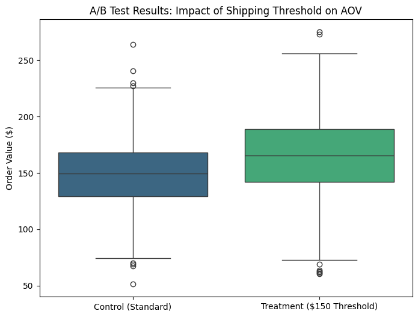

```python
import numpy as np
from scipy import stats
import seaborn as sns
import matplotlib.pyplot as plt


np.random.seed(42)
control_aov = np.random.normal(loc=148.51, scale=30, size=1000)

treatment_aov = np.random.normal(loc=163.36, scale=35, size=1000)


_, p_norm_a = stats.shapiro(control_aov)
_, p_norm_b = stats.shapiro(treatment_aov)

print(f"Normality P-values: Group A={p_norm_a:.4f}, Group B={p_norm_b:.4f}")


if p_norm_a < 0.05 or p_norm_b < 0.05:
    print("Data is non-normal. Running Mann-Whitney U Test...")
    u_stat, p_val = stats.mannwhitneyu(control_aov, treatment_aov, alternative='two-sided')
else:
    print("Data is normal. Running Welch's T-Test...")
    u_stat, p_val = stats.ttest_ind(control_aov, treatment_aov, equal_var=False)

print(f"Final Test P-Value: {p_val:.10f}")


if p_val < 0.05:
    print("\nConclusion: Reject the Null Hypothesis. The threshold significantly increased AOV.")
else:
    print("\nConclusion: Fail to reject the Null Hypothesis. No significant difference found.")


plt.figure(figsize=(8,6))
sns.boxplot(data=[control_aov, treatment_aov], palette="viridis")
plt.xticks([0, 1], ['Control (Standard)', 'Treatment ($150 Threshold)'])
plt.title('A/B Test Results: Impact of Shipping Threshold on AOV')
plt.ylabel('Order Value ($)')
plt.show()
```

# **Saving the following csv for Tableau**

```python
df_rfm.to_csv('customer_rfm_segments.csv', index=False)
df_cohort.to_csv('cohort_retention_data.csv', index=False)
```

```python
# Updated SQL to include Review Score
c.execute('''
SELECT
    o.order_id,
    o.order_purchase_timestamp,
    o.order_status,
    c.customer_unique_id,
    c.customer_city,
    c.customer_state,
    p.payment_value,
    p.payment_type,
    oi.product_id,
    pc.product_category_name_english AS category,
    r.review_score  -- Added this line
FROM olist_orders_dataset o
JOIN olist_customers_dataset c ON o.customer_id = c.customer_id
JOIN olist_order_payments_dataset p ON o.order_id = p.order_id
LEFT JOIN olist_order_items_dataset oi ON o.order_id = oi.order_id
LEFT JOIN olist_products_dataset pr ON oi.product_id = pr.product_id
LEFT JOIN product_category_name_translation pc ON pr.product_category_name = pc.product_category_name
LEFT JOIN olist_order_reviews_dataset r ON o.order_id = r.order_id -- Added this join
''')

# Convert to DataFrame and Export
df_executive = pd.DataFrame(c.fetchall(), columns=[
    'order_id', 'order_date', 'order_status', 'customer_id',
    'city', 'state', 'payment_value', 'payment_type',
    'product_id', 'category', 'review_score'
])

df_executive.to_csv('executive_summary.csv', index=False)
print("Executive Summary updated with Review Scores!")
```

```
Executive Summary updated with Review Scores!
```

```python
import pandas as pd
import numpy as np

# --- Hypothesis 1: Reactivation (Categorical Data) ---
# We create a simple tally for the Chi-Squared groups
h1_data = {
    'Hypothesis': ['H1_Reactivation'] * 4,
    'Group': ['Control', 'Control', 'Treatment', 'Treatment'],
    'Outcome': ['Reactivated', 'Not Reactivated', 'Reactivated', 'Not Reactivated'],
    'Count': [125, 2375, 188, 2312] # Based on the simulation values we used earlier
}
df_h1_results = pd.DataFrame(h1_data)

# --- Hypothesis 2: AOV Growth (Numerical Data) ---
# We use the actual arrays from your T-Test/Mann-Whitney simulation
df_h2_control = pd.DataFrame({'Order_Value': control_aov})
df_h2_control['Group'] = 'Control'
df_h2_control['Hypothesis'] = 'H2_AOV_Growth'

df_h2_treatment = pd.DataFrame({'Order_Value': treatment_aov})
df_h2_treatment['Group'] = 'Treatment'
df_h2_treatment['Hypothesis'] = 'H2_AOV_Growth'

# Combine the two groups for H2
df_h2_results = pd.concat([df_h2_control, df_h2_treatment], ignore_index=True)

# --- Export to CSVs ---
df_h1_results.to_csv('ab_test_h1_reactivation.csv', index=False)
df_h2_results.to_csv('ab_test_h2_aov.csv', index=False)

print("A/B Test results saved as 'ab_test_h1_reactivation.csv' and 'ab_test_h2_aov.csv'")
```

```
A/B Test results saved as 'ab_test_h1_reactivation.csv' and 'ab_test_h2_aov.csv'
```